# Effects of urban green infrastructure on supply provision of ecosystem service: Temperature reduction

Irina Lerner

30/01/24

# Aim and scope

*CLEAR AIM:* TO SHOW THE EFFECT OF VEGETATION CONFIGURATION IN MEAN TEMPERATURE.

Here we show results, flow and maybe missing steps

# Data

DATA NEEDS URGENT CARE: - SEE IF ITS BETTER USING VI PROPORTIONS WITH OR WITHOUT NA. PROBLY WITH NA IF WE ARE CONSIDERING OTHER VARIABLES - PROP_WATER AND PROP_GRASS THAT ARE NOT CORRECTLY CALCULATED FROM THE MAPS

# Exploratory Analysis

## Response

We begin exploring the response data.

```r
analyse_model(data, lm(T_mean ~ 1, data))
```

```
## [1] "Residuals not normally distributed:"
## [1] -0.2141189
##
##  Moran I test under randomisation
##
## data:  residuals(model)
## weights: listw
##
## Moran I statistic standard deviate = 736.58, p-value < 2.2e-16
## alternative hypothesis: greater
## sample estimates:
## Moran I statistic       Expectation          Variance
##      9.653109e-01     -6.748504e-06      1.717531e-06
```

```
## [1] 898590.2
```

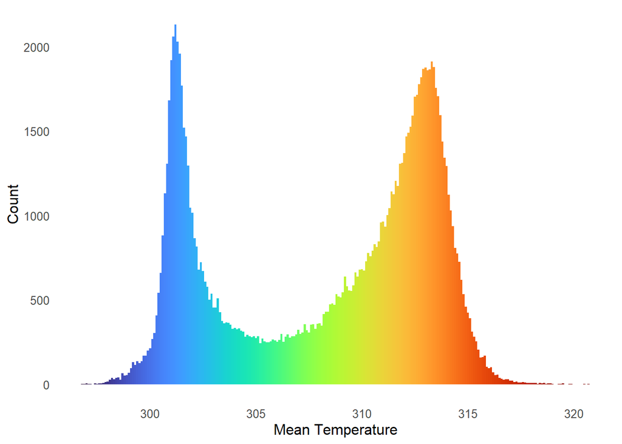

```r
ggplot(cdata, aes(x = T_mean)) +
      geom_histogram(aes(fill = as.factor(cut_width(T_mean, 0.1))), binwidth = 0.1, color = NA) +
      scale_fill_viridis_d(option = "turbo", guide = FALSE) +
      labs(title = "Distribution of T_mean by Bin Order", x = "Mean Temperature", y = "Count") +
      custom_theme
```

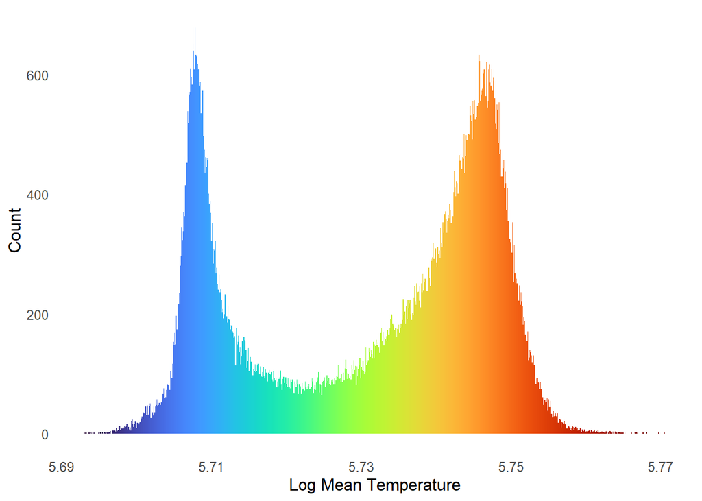

```r
ggplot(cdata, aes(x = log(T_mean))) +
      geom_histogram(aes(fill = as.factor(cut_width(log(T_mean), 0.0001))), binwidth = 0.0001, color = NA) +
      scale_fill_viridis_d(option = "turbo", guide = FALSE) +
      labs(title = "Distribution of T_mean by Bin Order", x = "Log Mean Temperature", y = "Count") +
      custom_theme
```

From the distribution of DT in this grid comparison, the values are not normally distributed, instead, they have two peaks.

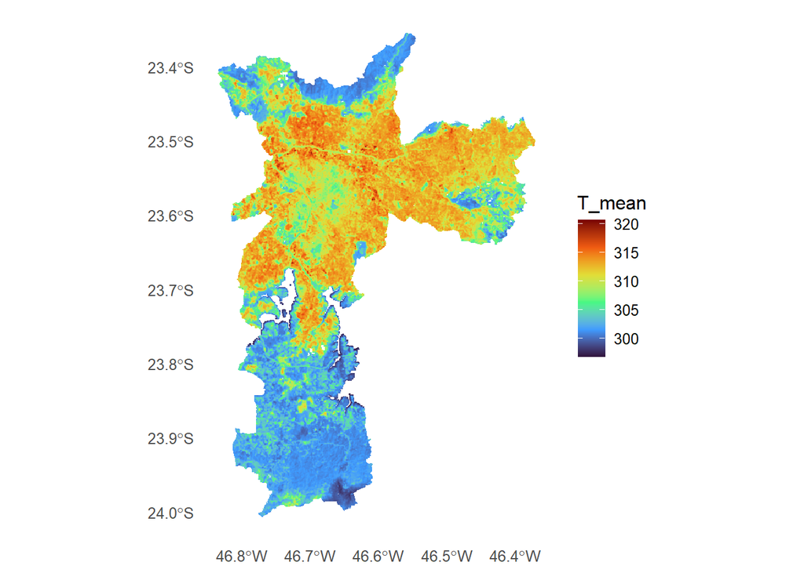

```r
ggplot(data) +
  geom_sf(aes(fill = T_mean), color = NA) +  # Correct usage of color setting
  scale_fill_viridis_c(option = "turbo") +
  custom_theme
```

## Predictors

This two peaks can be seen when we take the distribution of each micro climatic region

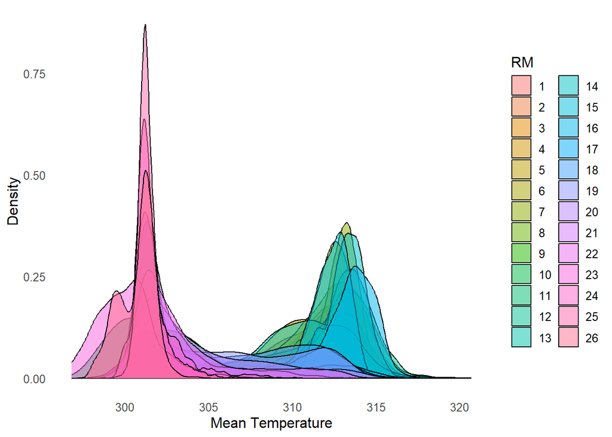

```r
ggplot(cdata, aes(x = T_mean, fill = factor(RM))) +
  geom_density(alpha = 0.5) +
  labs(x = "Mean Temperature", y = "Density", fill = "RM") +
  custom_theme
```

we can either normalize by micro climatic region or consider it as a random effect in the distribution parameters.

But looking at the distribution of São Paulo mean EVI values in the 100m² grid, we see again the peaks,

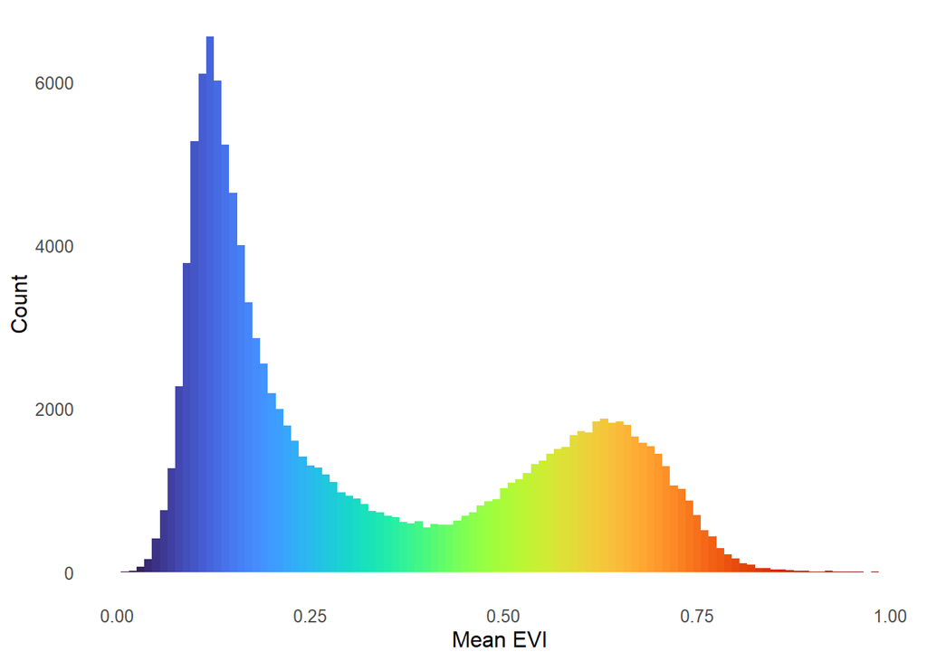

```r
ggplot(cdata, aes(x = EVI_mean)) +
      geom_histogram(aes(fill = as.factor(cut_width(EVI_mean, 0.01))), binwidth = 0.01, color = NA) +
      scale_fill_viridis_d(option = "turbo", guide = FALSE) +
      labs(x = "Mean EVI", y = "Count") +
      custom_theme
```

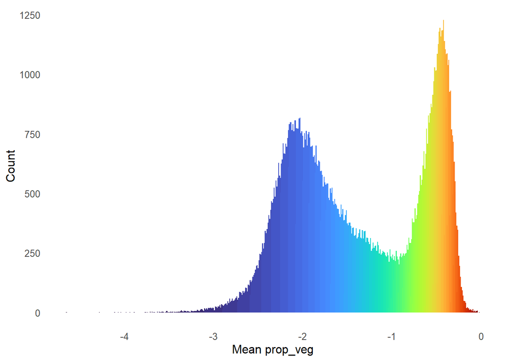

```r
ggplot(cdata, aes(x = log(EVI_mean))) +
      geom_histogram(aes(fill = as.factor(cut_width(EVI_mean, 0.01))), binwidth = 0.01, color = NA) +
      scale_fill_viridis_d(option = "turbo", guide = FALSE) +
      labs(title = "Distribution of prop_veg by Bin Order", x = "Mean prop_veg", y = "Count") +
      custom_theme
```

Plotting the histogram divided by micro climatic region gives us the peaks again, indicating similar pattern found in the last image.

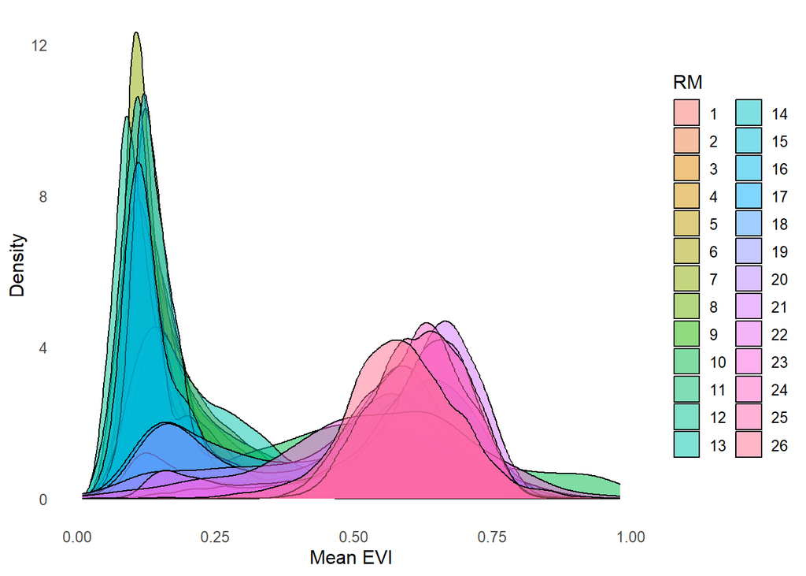

```r
ggplot(cdata, aes(x = EVI_mean, fill = factor(RM))) +
  geom_density(alpha = 0.5) +
  labs(title = "Density Plot of mean EVI by Microclimatic region", x = "Mean EVI", y = "Density", fill = "RM") +
  custom_theme
```

This implies that micro climatic regions are way different in vegetation and that might be what is responsible for this situation. But we can visually conclude that the number of places with low temperature peaks higher than the number of places with high EVI.

When we look at proportion of vegetation distribution we see what might lie behind this effect. While the high temperature and low vegetation peaks kind of match, the high EVI doesn’t correspond to the peak, but wee see that São Paulo has more fully vegetated patches than anything else.

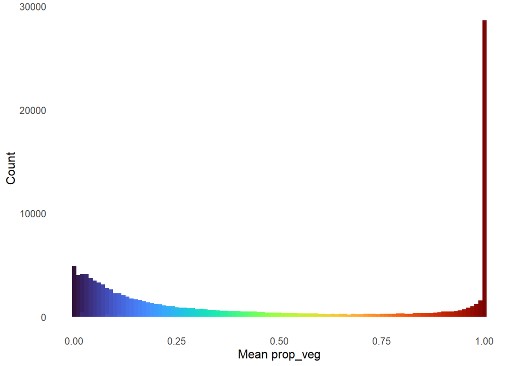

```r
ggplot(cdata, aes(x = prop_veg)) +
      geom_histogram(aes(fill = as.factor(cut_width(prop_veg, 0.01))), binwidth = 0.01, color = NA) +
      scale_fill_viridis_d(option = "turbo", guide = FALSE) +
      labs(title = "Distribution of prop_veg by Bin Order", x = "Mean prop_veg", y = "Count") +
      custom_theme
```

Some hypothesis can be drawn from that. In particular, that the effect of vegetation in temperature is not linear, but increases with the increase in vegetation. Also, that we might be seeing an spatial effect of vegetation, where it not only reduces local temperature but can cool down neighboring regions. Lets explore those hypothesis.

Let’s see the maps overlaying

```
##
##   1-1   1-2   1-3   2-1   2-2   2-3   3-1   3-2   3-3
##  2494  2243 49084 11325  8912 10923 54828  6811  1562
```

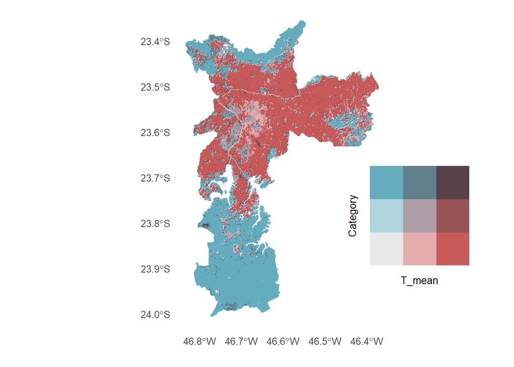

```r
plot_bi_map(data, "T_mean", "Category")
```

Combinations of low proportion of vegetation and low mean temperature seem to be around water, forest borders, and in a specific region in the center of the city. In the reserves, we see low temperature and high vegetation. In the urban part of the city we see low vegetation with high temperature as expected.

We can also check the bi scale plots for other variables

```
##
##   1-1   1-2   1-3   2-1   2-2   2-3   3-1   3-2   3-3
##   131 11705 28734  5470 16626  2370 39021 19251   192
```

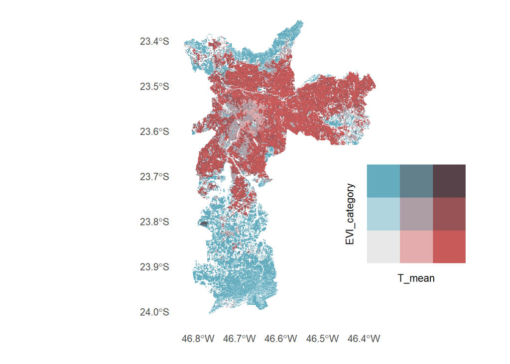

```r
plot_bi_map(cdata, "T_mean", "EVI_category")
```

Lets check for our response variables

```
##
##   1-1   1-2   1-3   2-1   2-2   2-3   3-1   3-2   3-3
## 25121  9317  6683  5432  8137 11638 28662 18159 10351
```

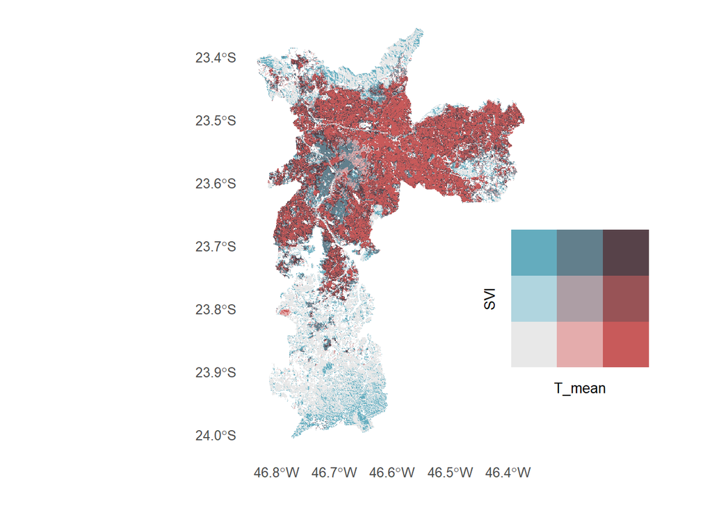

```r
plot_bi_map(cdata, "T_mean", "SVI")
```

```
##
##   1-1   1-2   1-3   2-1   2-2   2-3   3-1   3-2   3-3
##  6244 11127 23644 20771  2690  1401 57039   475   109
```

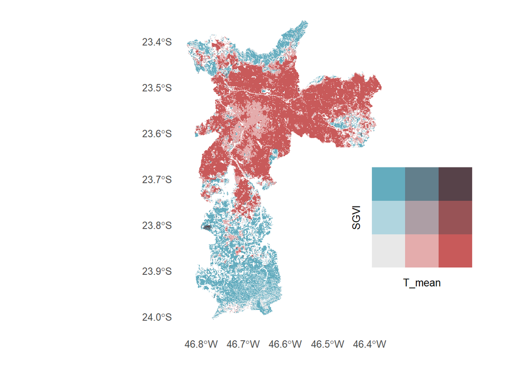

```r
plot_bi_map(cdata, "T_mean", "SGVI")
```

```
##
##   1-1   1-2   1-3   2-1   2-2   2-3   3-1   3-2   3-3
## 40102   339    62 15282  5794  2787 10200 21249 27685
```

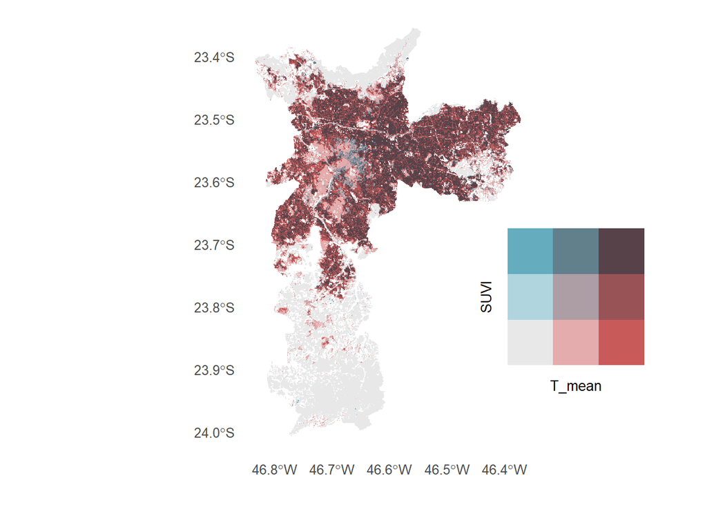

```r
plot_bi_map(cdata, "T_mean", "SUVI")
```

The variables are highly colinear, as we can see in pairwise correlation

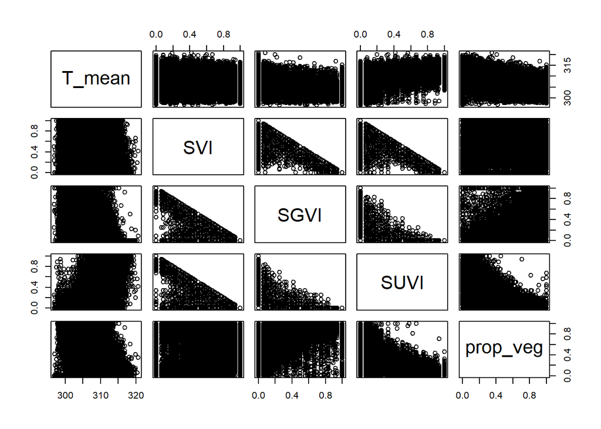

```r
predictors <- c("T_mean",
                "SVI",
                "SGVI",
                "SUVI",
                "prop_veg")

pairs(as.data.frame(cdata)[, predictors])
```

whe can see high correlation among predictor variables. Lets check the colective explained variance from each variable in our data_frame

we will separate variables in urban elements and vegetation elements. First, we see how much explained variance there is among EVI and prop_veg

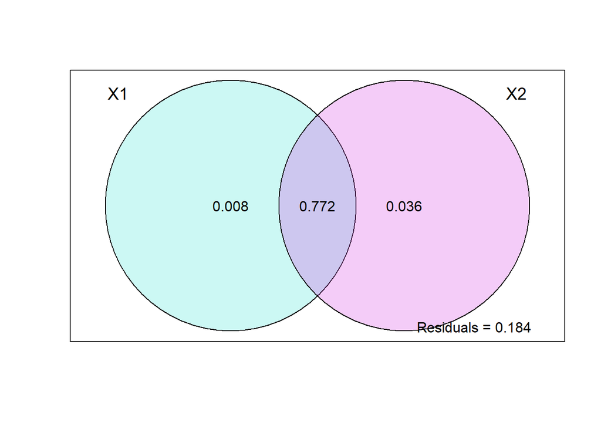

```r
data_df <- as.data.frame(cdata)
part.lm = varpart(data_df$T_mean, data_df[, c("EVI_mean")], data_df[, c("prop_veg")])
# Plot with custom settings
plot(part.lm, digits = 2,
     bg = c(rgb(48, 225, 210, 80, maxColorValue = 255),
            rgb(210, 48, 225, 80, maxColorValue = 255)))
```

```r
out1 <- rda(data_df$DT, data_df[, c("EVI_mean")], data_df[, c("prop_veg")])
out2 <- rda(data_df$DT, data_df[, c("prop_veg")], data_df[, c("EVI_mean")])

anova(out1, step = 1000, perm.max = 1000)
```

```
## Permutation test for rda under reduced model
## Permutation: free
## Number of permutations: 999
##
## Model: rda(X = data_df$DT, Y = data_df[, c("EVI_mean")], Z = data_df[, c("prop_veg")])
##              Df Variance      F Pr(>F)
## Model         1   0.0617 1043.9  0.001 ***
## Residual 123497   7.2970
## ---
## Signif. codes:  0 '***' 0.001 '**' 0.01 '*' 0.05 '.' 0.1 ' ' 1
```

```r
anova(out2, step = 1000, perm.max = 1000)
```

```
## Permutation test for rda under reduced model
## Permutation: free
## Number of permutations: 999
##
## Model: rda(X = data_df$DT, Y = data_df[, c("prop_veg")], Z = data_df[, c("EVI_mean")])
##              Df Variance    F Pr(>F)
## Model         1   0.4228 7155  0.001 ***
## Residual 123497   7.2970
## ---
## Signif. codes:  0 '***' 0.001 '**' 0.01 '*' 0.05 '.' 0.1 ' ' 1
```

We see that EVI and proporion of vegetation Explain most of the variables together

If we split EVI in our three occupation variables, we can see how much variance is left

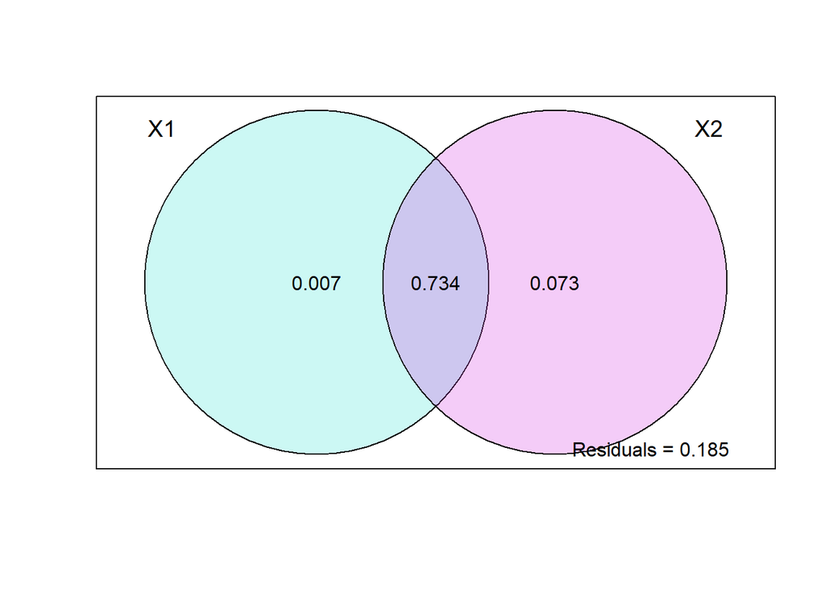

```r
part.lm = varpart(data_df$T_mean, data_df[, c("SVI", "SUVI", "SGVI")], data_df[, c("prop_veg")])
# Plot with custom settings
plot(part.lm, digits = 2,
     bg = c(rgb(48, 225, 210, 80, maxColorValue = 255),
            rgb(210, 48, 225, 80, maxColorValue = 255)))
```

There is 18% of the variance not accounted for. Just to show, lets try and include all the variables we have.

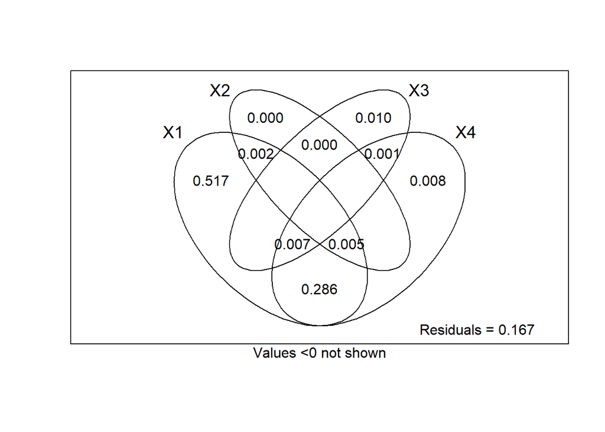

```r
part.lm = varpart(data_df$T_mean, data_df[, c("SGVI", "prop_veg")], data_df[, c("SVI")], data_df[, c("water_prop")], data_df[, c("centx", "centy")])
# Plot with custom settings
plot(part.lm, digits = 2)
```

Again, most of the variance is explained by prop_veg. Let’s add some spatiallity

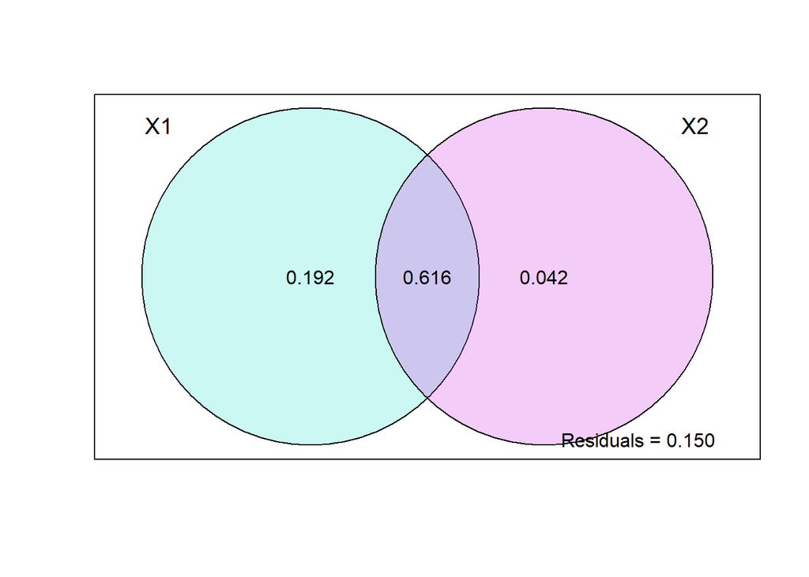

```r
part.lm = varpart(data_df$T_mean, data_df[, c("prop_veg")], data_df[, c("RM_fac")])
# Plot with custom settings
plot(part.lm, digits = 2,
     bg = c(rgb(48, 225, 210, 80, maxColorValue = 255),
            rgb(210, 48, 225, 80, maxColorValue = 255)))
```

We can see that most of the variance is explained together.

Combining multiple variables in one plot gives us

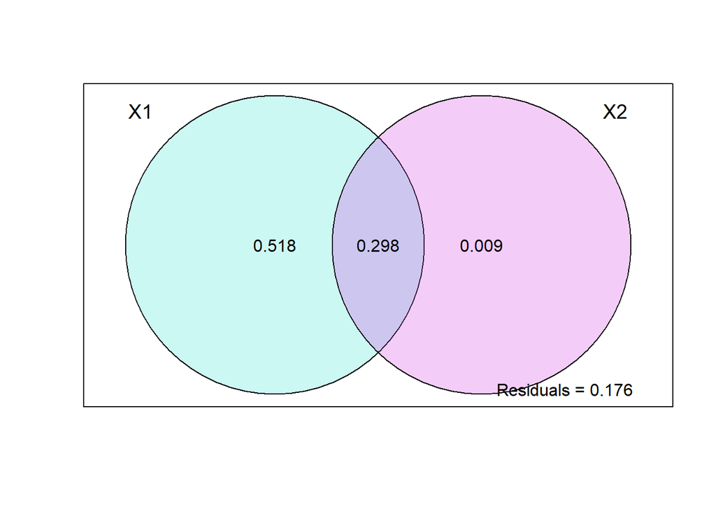

```r
part.lm = varpart(data_df$T_mean, data_df[, c("EVI_mean","prop_veg")], data_df[, c("centx", "centy")])
# Plot with custom settings
plot(part.lm, digits = 2,
     bg = c(rgb(48, 225, 210, 80, maxColorValue = 255),
            rgb(210, 48, 225, 80, maxColorValue = 255)))
```

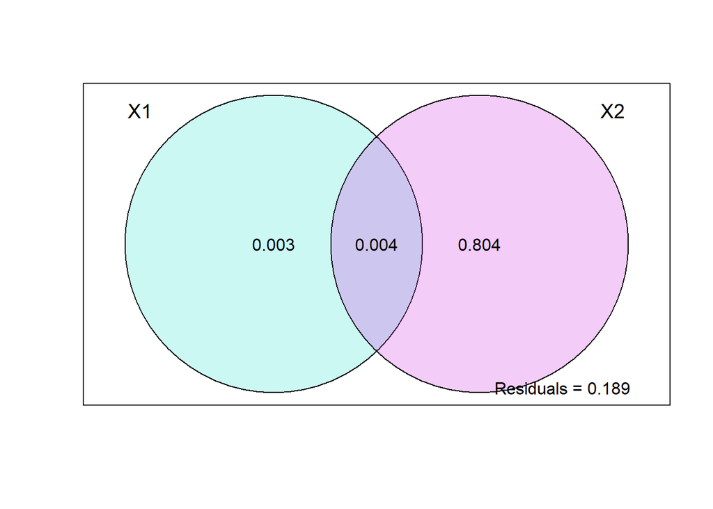

```r
part.lm = varpart(data_df$T_mean, data_df[, c("SVI")], data_df[, c("prop_veg")])
# Plot with custom settings
plot(part.lm, digits = 2,
     bg = c(rgb(48, 225, 210, 80, maxColorValue = 255),
            rgb(210, 48, 225, 80, maxColorValue = 255)))
```

Comparing SVI and proportion of vegetation we can see that SVI does not play a big part in the variance fot temperature control, in the scale of 100x100.

But variance partitioning is just one element that might indicate goodness of fit. Another one is AIC. Comparing the linearity between prop_veg and T and also EVI and T, we see:

```r
model_pv <- lm(T_mean ~ prop_veg, data)
analyse_model(data, model_pv, moran = T)
```

```
## [1] "Residuals not normally distributed:"
## [1] -1.105641
##
##  Moran I test under randomisation
##
## data:  residuals(model)
## weights: listw
##
## Moran I statistic standard deviate = 483.46, p-value < 2.2e-16
## alternative hypothesis: greater
## sample estimates:
## Moran I statistic       Expectation          Variance
##      6.335687e-01     -6.748504e-06      1.717448e-06
```

```
## [1] 717232.4
```

```r
model_EVI <- lm(T_mean ~ EVI_mean, cdata)
analyse_model(cdata, model_EVI, moran = T)
```

```
## [1] "Residuals not normally distributed:"
## [1] -0.1423749
##
##  Moran I test under randomisation
##
## data:  residuals(model)
## weights: listw
## n reduced by no-neighbour observations
##
## Moran I statistic standard deviate = 369.87, p-value < 2.2e-16
## alternative hypothesis: greater
## sample estimates:
## Moran I statistic       Expectation          Variance
##      5.675390e-01     -8.104779e-06      2.354599e-06
```

```
## [1] 565653.4
```

```r
model_EVI_log <- lm(T_mean ~ log(EVI_mean), cdata)
analyse_model(cdata, model_EVI_log, moran = T)
```

```
## [1] "Residuals not normally distributed:"
## [1] 0.1234112
##
##  Moran I test under randomisation
##
## data:  residuals(model)
## weights: listw
## n reduced by no-neighbour observations
##
## Moran I statistic standard deviate = 369.32, p-value < 2.2e-16
## alternative hypothesis: greater
## sample estimates:
## Moran I statistic       Expectation          Variance
##      5.666994e-01     -8.104779e-06      2.354615e-06
```

```
## [1] 587359.3
```

Looking at the Moran I test we still see a lot of spatial correlation. But the distribution with EVI is less skewed and less spatially correlated. Still, there is a lot of correlation.

```
##
##   1-1   1-2   1-3   2-1   2-2   2-3   3-1   3-2   3-3
## 26241  7551  8888 13890  9507 32073   270  6728 18352
```

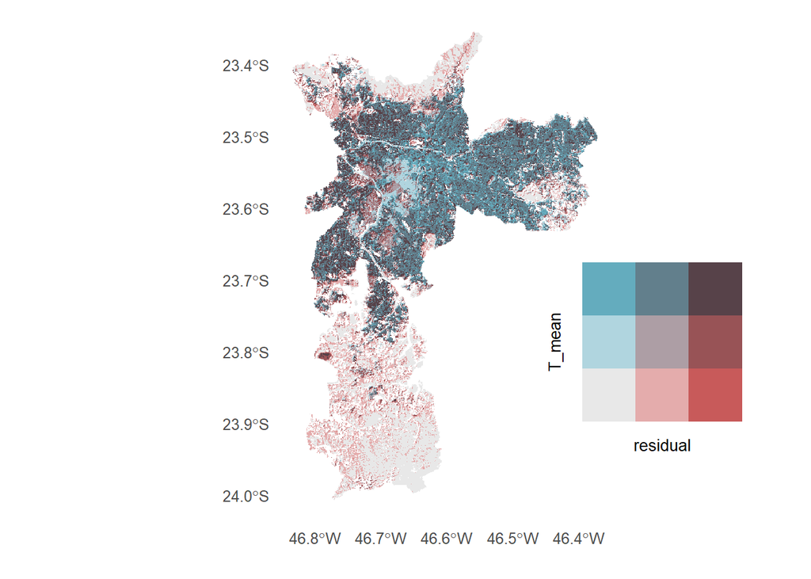

```r
linear <- lm(T_mean ~ log(EVI_mean), cdata)

cdata$residual <- resid(linear)

plot_bi_map(cdata, "residual", "T_mean", "viridis")
```

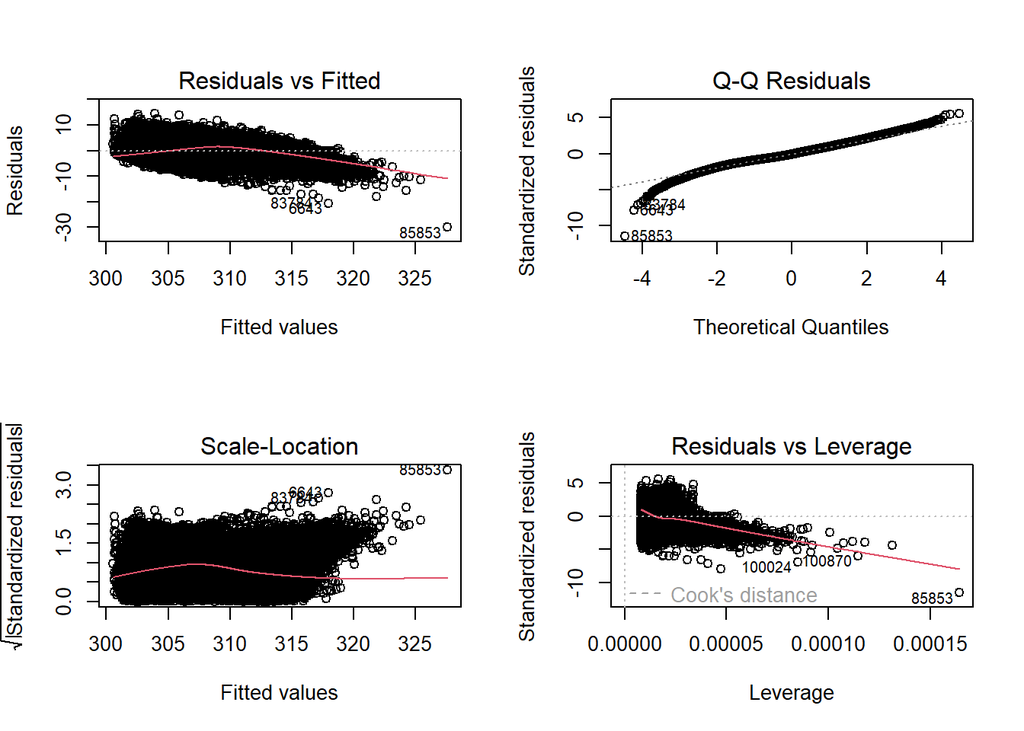

```r
par(mfrow = c(2,2))
plot(linear)
```

Since the residuals seem nonlinear, using GAM might be a good option to explore the complexity of this relationship.

```r
library(mgcv)

gam_EVI <- gam(T_mean ~ s(EVI_mean, k = 50), data = cdata, method = "ML")
AIC(gam_EVI)
```

```
## [1] 551842.8
```

```r
k.check(gam_EVI)
```

```
##             k'      edf   k-index p-value
## s(EVI_mean) 49 20.64286 0.9936901   0.335
```

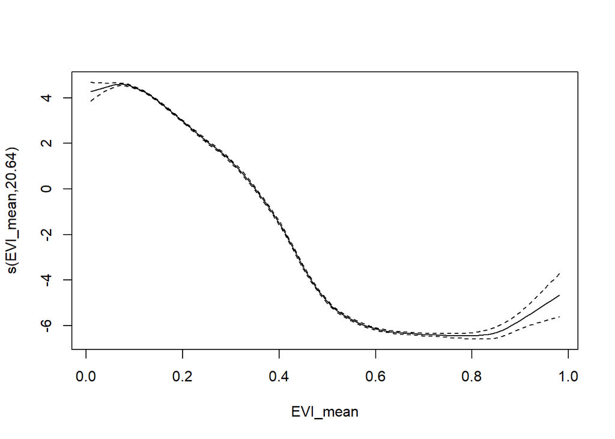

```r
plot(gam_EVI, all.terms = TRUE)
```

The k-check shows that we’ve given enough degrees of freedom for the model to search for the best fit. ML method makes it comparable with other models.

```r
gam_PV <- gam(T_mean ~ s(prop_veg, k = 50), data = cdata, method = "ML")
AIC(gam_PV)
```

```
## [1] 543150.8
```

```r
k.check(gam_PV)
```

```
##             k'      edf  k-index p-value
## s(prop_veg) 49 32.38779 1.027096  0.9625
```

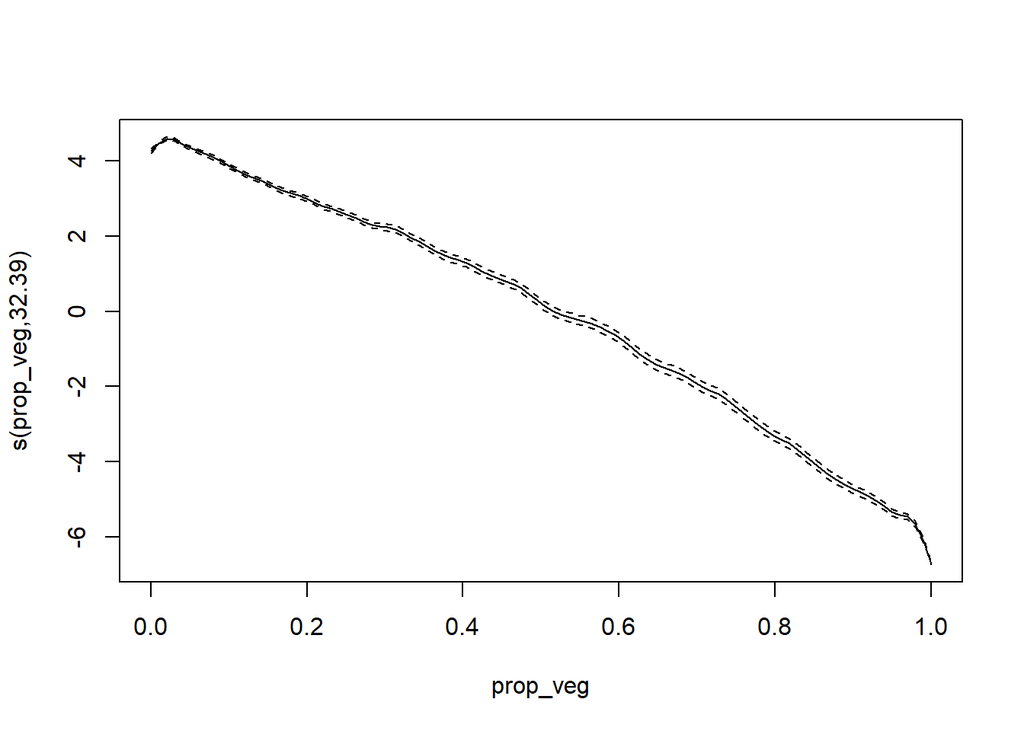

```r
plot(gam_PV, all.terms = TRUE)
```

```r
gam_SVI_cat <- gam(T_mean ~ s(SVI, by = Category), data = cdata, method = "ML")
AIC(gam_SVI_cat)
```

```
## [1] 735884.6
```

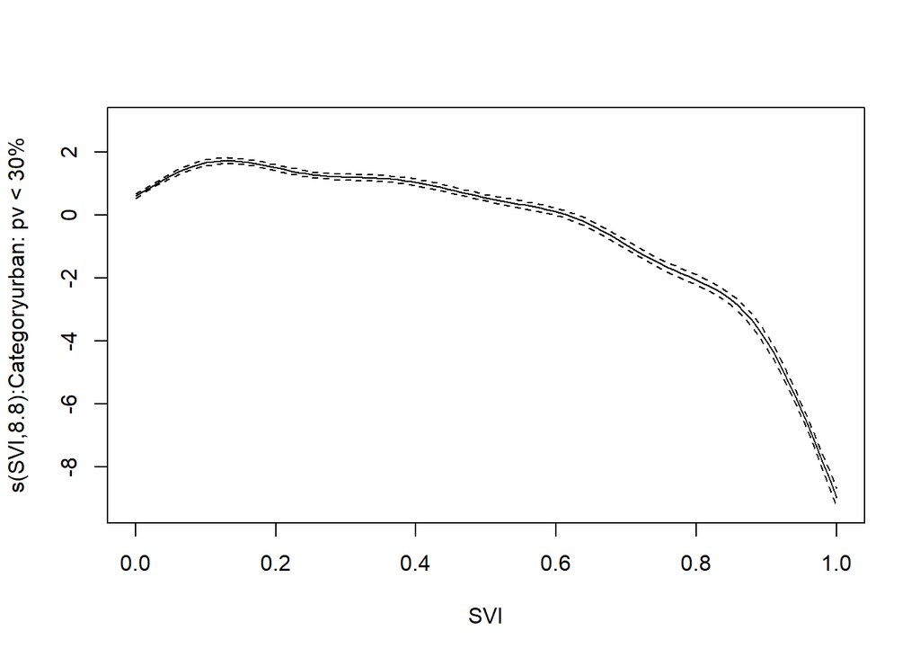

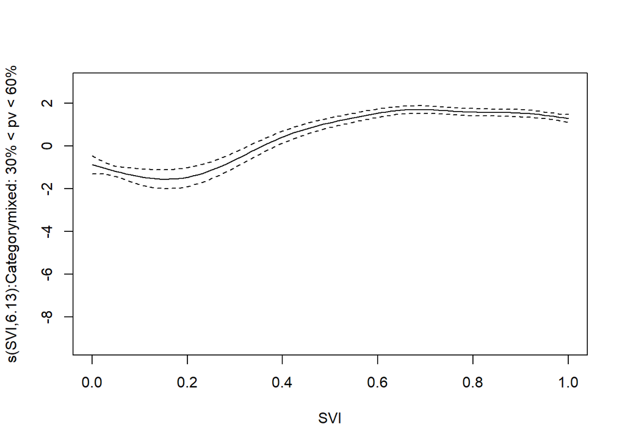

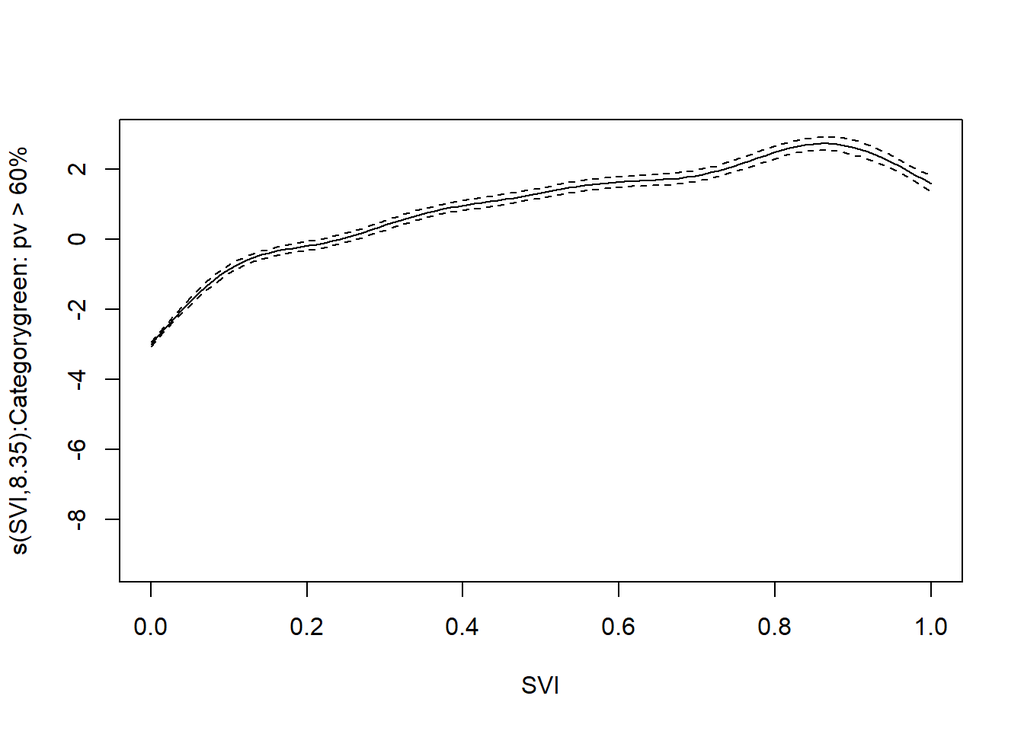

```r
plot(gam_SVI_cat, all.terms = TRUE)
```

```r
gam_SEVI_cat <- gam(T_mean ~ s(SEVI2, by = Category), data = cdata, method = "ML")
AIC(gam_SEVI_cat)
```

```
## [1] 551920.8
```

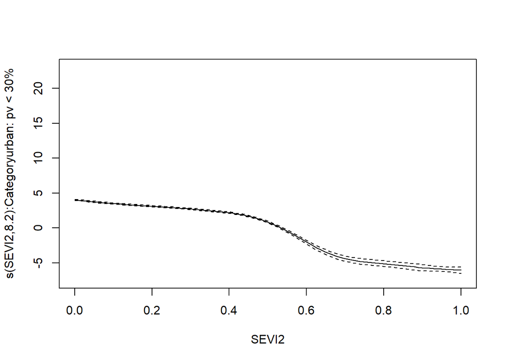

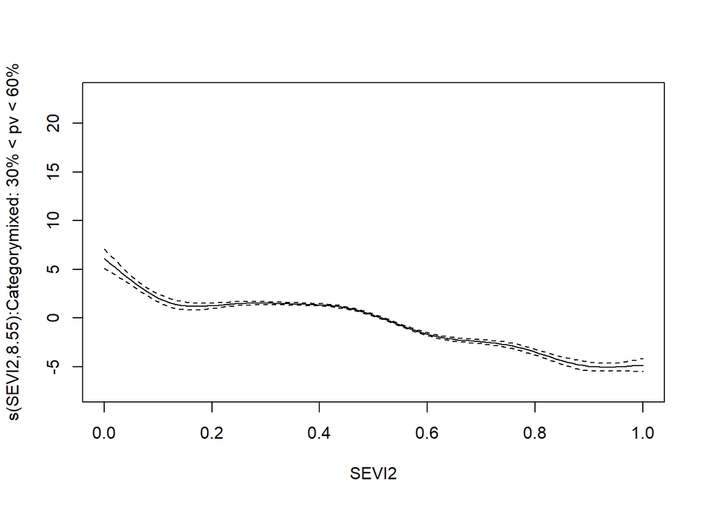

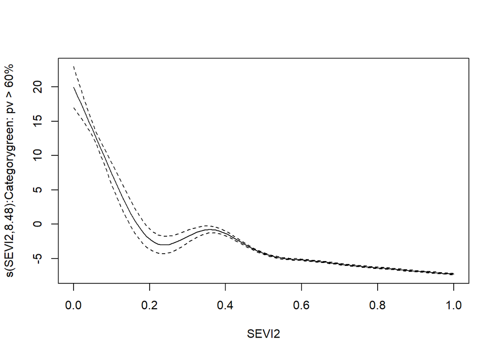

```r
plot(gam_SEVI_cat, all.terms = TRUE)
```